# White Wine Quality

This data set described the chemical properties and quality of the White Wines.

# Univariate Plots Section

```
## [1] 4898   13
```

```
## 'data.frame':    4898 obs. of  13 variables:
##  $ X                   : int  1 2 3 4 5 6 7 8 9 10 ...
##  $ fixed.acidity       : num  7 6.3 8.1 7.2 7.2 8.1 6.2 7 6.3 8.1 ...
##  $ volatile.acidity    : num  0.27 0.3 0.28 0.23 0.23 0.28 0.32 0.27 0.3 0.22 ...
##  $ citric.acid         : num  0.36 0.34 0.4 0.32 0.32 0.4 0.16 0.36 0.34 0.43 ...
##  $ residual.sugar      : num  20.7 1.6 6.9 8.5 8.5 6.9 7 20.7 1.6 1.5 ...
##  $ chlorides           : num  0.045 0.049 0.05 0.058 0.058 0.05 0.045 0.045 0.049 0.044 ...
##  $ free.sulfur.dioxide : num  45 14 30 47 47 30 30 45 14 28 ...
##  $ total.sulfur.dioxide: num  170 132 97 186 186 97 136 170 132 129 ...
##  $ density             : num  1.001 0.994 0.995 0.996 0.996 ...
##  $ pH                  : num  3 3.3 3.26 3.19 3.19 3.26 3.18 3 3.3 3.22 ...
##  $ sulphates           : num  0.45 0.49 0.44 0.4 0.4 0.44 0.47 0.45 0.49 0.45 ...
##  $ alcohol             : num  8.8 9.5 10.1 9.9 9.9 10.1 9.6 8.8 9.5 11 ...
##  $ quality             : int  6 6 6 6 6 6 6 6 6 6 ...
```

```
##        X        fixed.acidity    volatile.acidity  citric.acid
##  Min.   :   1   Min.   : 3.800   Min.   :0.0800   Min.   :0.0000
##  1st Qu.:1225   1st Qu.: 6.300   1st Qu.:0.2100   1st Qu.:0.2700
##  Median :2450   Median : 6.800   Median :0.2600   Median :0.3200
##  Mean   :2450   Mean   : 6.855   Mean   :0.2782   Mean   :0.3342
##  3rd Qu.:3674   3rd Qu.: 7.300   3rd Qu.:0.3200   3rd Qu.:0.3900
##  Max.   :4898   Max.   :14.200   Max.   :1.1000   Max.   :1.6600
##  residual.sugar     chlorides       free.sulfur.dioxide
##  Min.   : 0.600   Min.   :0.00900   Min.   :  2.00
##  1st Qu.: 1.700   1st Qu.:0.03600   1st Qu.: 23.00
##  Median : 5.200   Median :0.04300   Median : 34.00
##  Mean   : 6.391   Mean   :0.04577   Mean   : 35.31
##  3rd Qu.: 9.900   3rd Qu.:0.05000   3rd Qu.: 46.00
##  Max.   :65.800   Max.   :0.34600   Max.   :289.00
##  total.sulfur.dioxide    density             pH          sulphates
##  Min.   :  9.0        Min.   :0.9871   Min.   :2.720   Min.   :0.2200
##  1st Qu.:108.0        1st Qu.:0.9917   1st Qu.:3.090   1st Qu.:0.4100
##  Median :134.0        Median :0.9937   Median :3.180   Median :0.4700
##  Mean   :138.4        Mean   :0.9940   Mean   :3.188   Mean   :0.4898
##  3rd Qu.:167.0        3rd Qu.:0.9961   3rd Qu.:3.280   3rd Qu.:0.5500
##  Max.   :440.0        Max.   :1.0390   Max.   :3.820   Max.   :1.0800
##     alcohol         quality
##  Min.   : 8.00   Min.   :3.000
##  1st Qu.: 9.50   1st Qu.:5.000
##  Median :10.40   Median :6.000
##  Mean   :10.51   Mean   :5.878
##  3rd Qu.:11.40   3rd Qu.:6.000
##  Max.   :14.20   Max.   :9.000
```

This data set contains 13 variables and about 4900 observation on White wines.

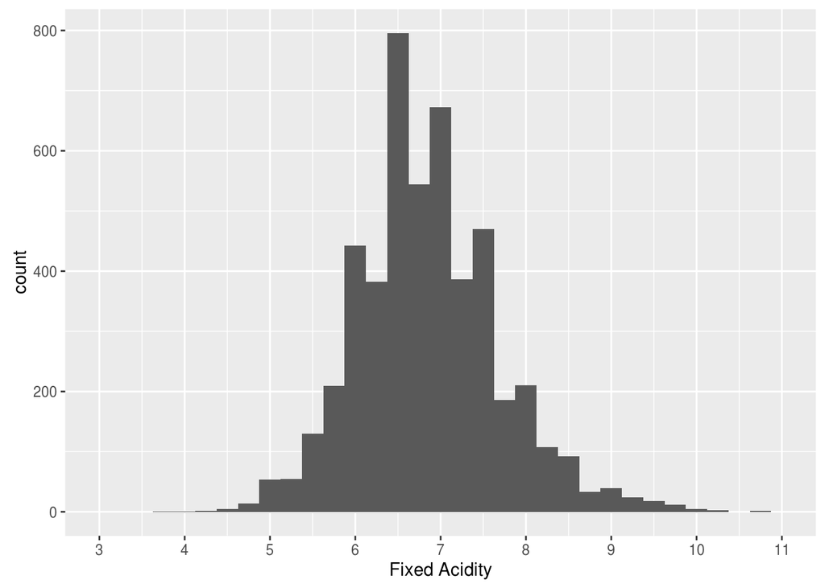

```
##    Min. 1st Qu.  Median    Mean 3rd Qu.    Max.
##   3.800   6.300   6.800   6.855   7.300  14.200
```

```
##  [1]  7.00  6.30  8.10  7.20  6.20  8.60  7.90  6.60  8.30  7.40  6.50
## [12]  6.40  6.80  7.60  6.90  8.50  5.80  7.30  6.70  6.00  7.10  6.10
## [23]  7.50  9.80  5.50  5.90  7.80  5.70  8.20  5.60  5.20  8.40 10.20
## [34]  7.70  5.30  5.40  9.10  5.00  8.00 10.00  5.10  9.20  9.00  8.80
## [45]  8.70  4.80 10.30  9.40  9.60  9.30  8.90  9.70 10.70 14.20  9.90
## [56]  9.50 11.80  4.60  6.15  4.50  7.15  6.45  4.20  4.90  4.70  3.80
## [67]  4.40  3.90
```

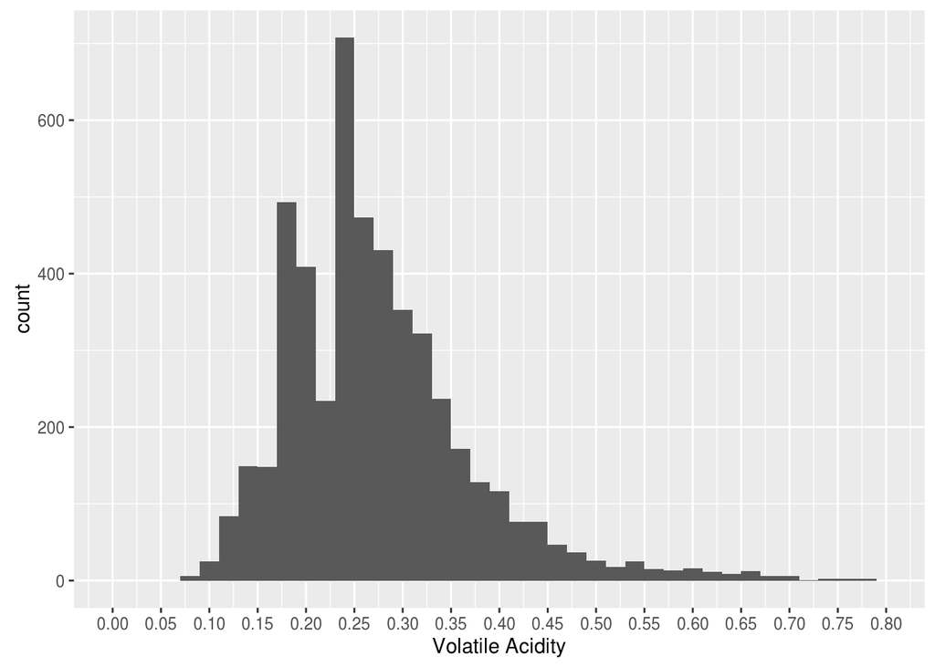

```
##    Min. 1st Qu.  Median    Mean 3rd Qu.    Max.
##  0.0800  0.2100  0.2600  0.2782  0.3200  1.1000
```

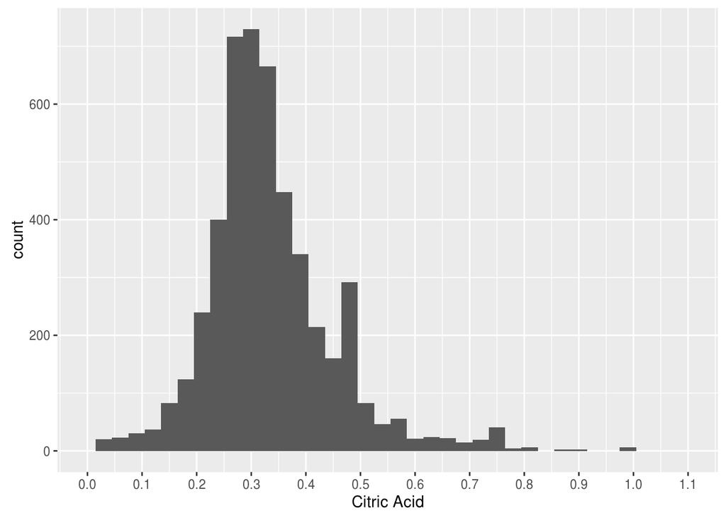

```
##    Min. 1st Qu.  Median    Mean 3rd Qu.    Max.
##  0.0000  0.2700  0.3200  0.3342  0.3900  1.6600
```

Most of the wines have the volatile acidity and citric acid in b/w 0.2 to 0.5.

As like acidity there many other variables describes the chemical properties of white wines.

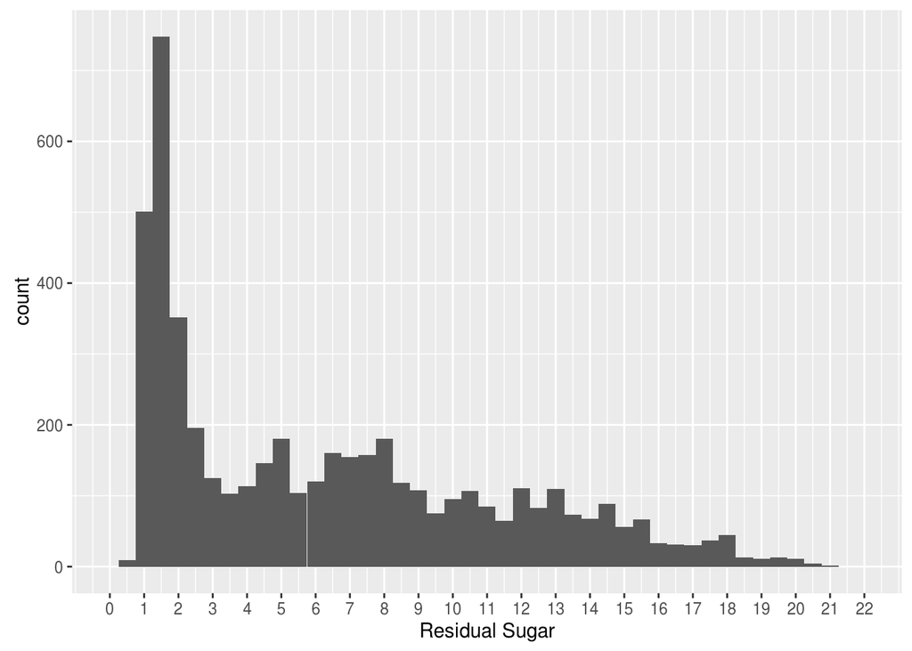

```
##    Min. 1st Qu.  Median    Mean 3rd Qu.    Max.
##   0.600   1.700   5.200   6.391   9.900  65.800
```

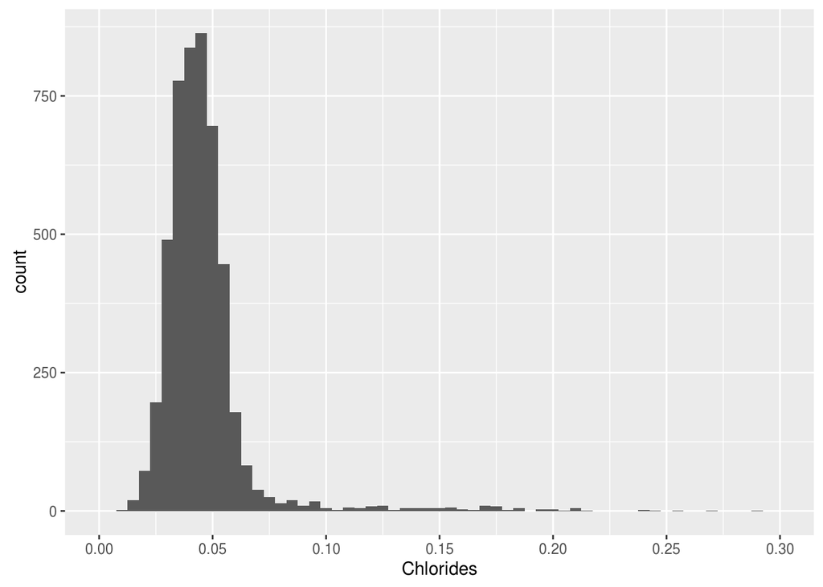

[output not shown]

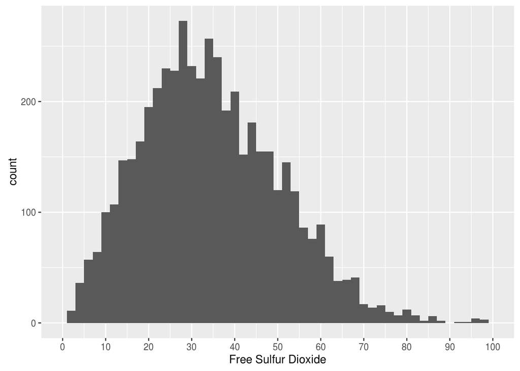

```
##    Min. 1st Qu.  Median    Mean 3rd Qu.    Max.
##    2.00   23.00   34.00   35.31   46.00  289.00
```

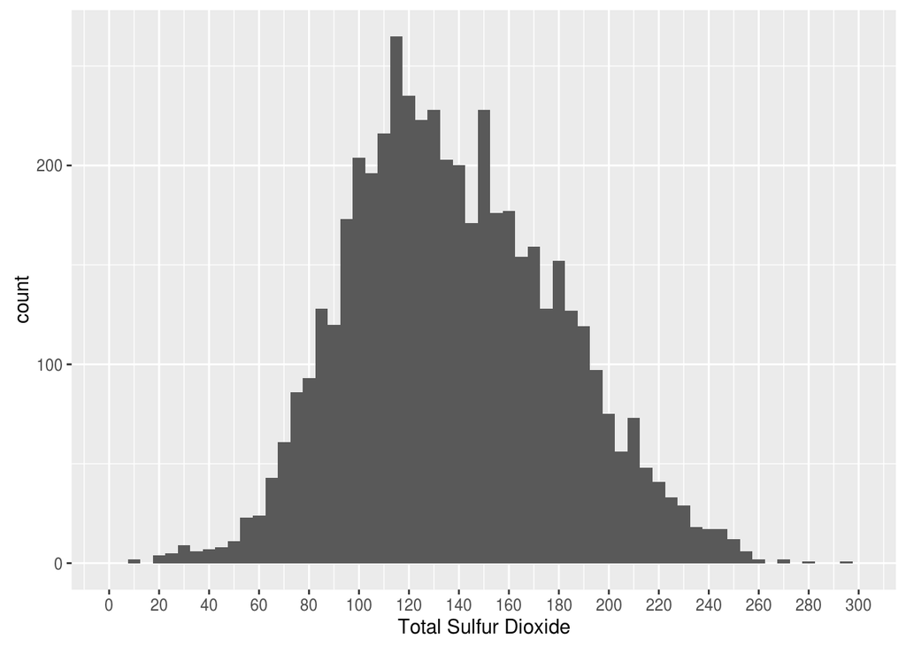

```
##    Min. 1st Qu.  Median    Mean 3rd Qu.    Max.
##     9.0   108.0   134.0   138.4   167.0   440.0
```

```
##    Min. 1st Qu.  Median    Mean 3rd Qu.    Max.
##  0.9871  0.9917  0.9937  0.9940  0.9961  1.0390
```

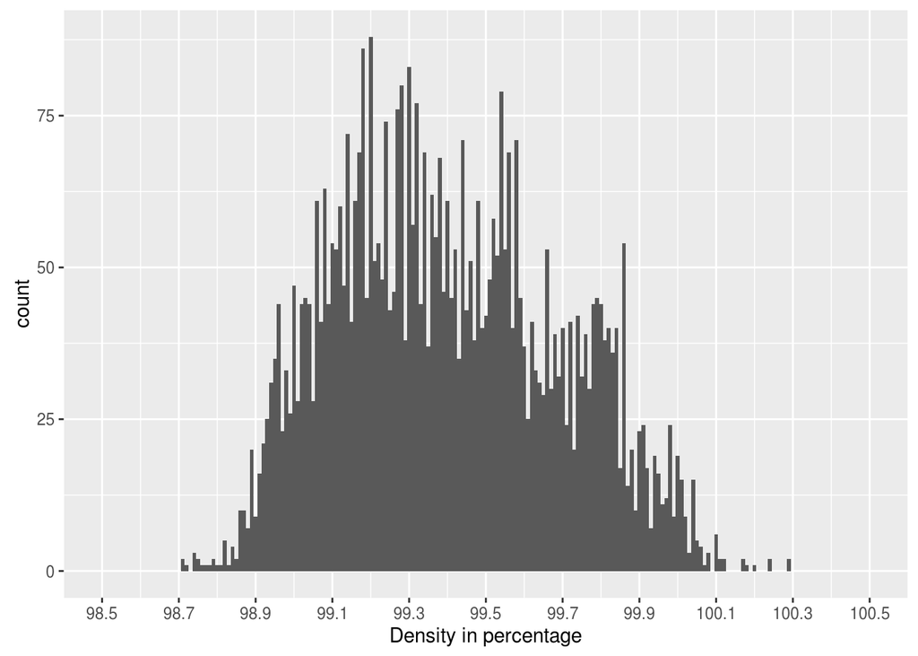

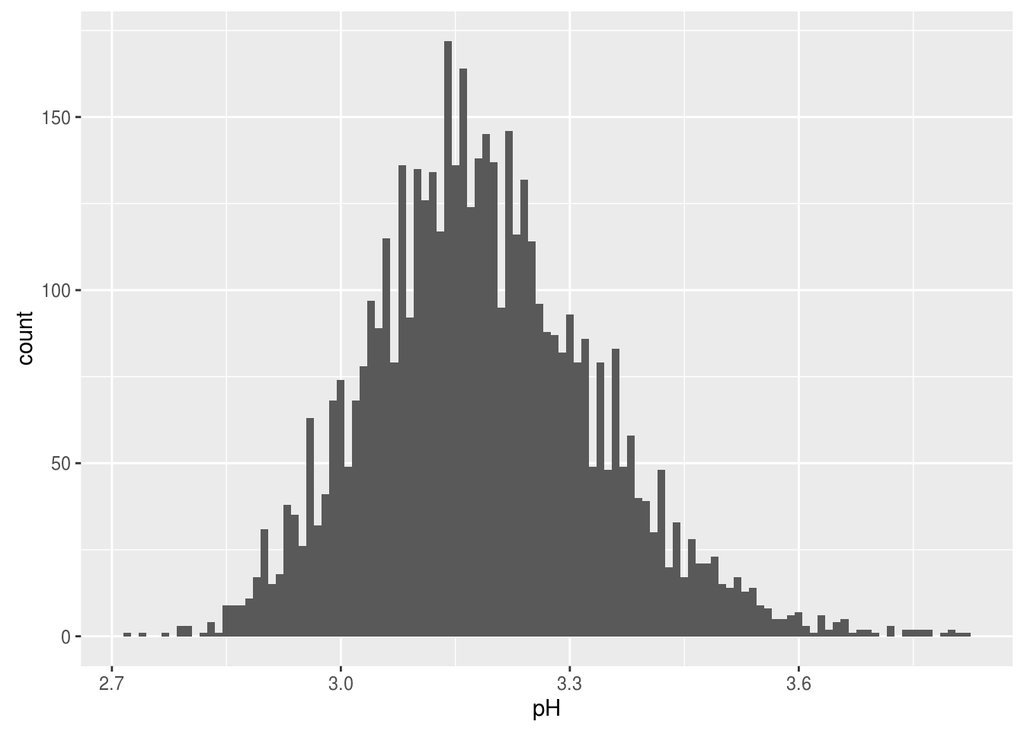

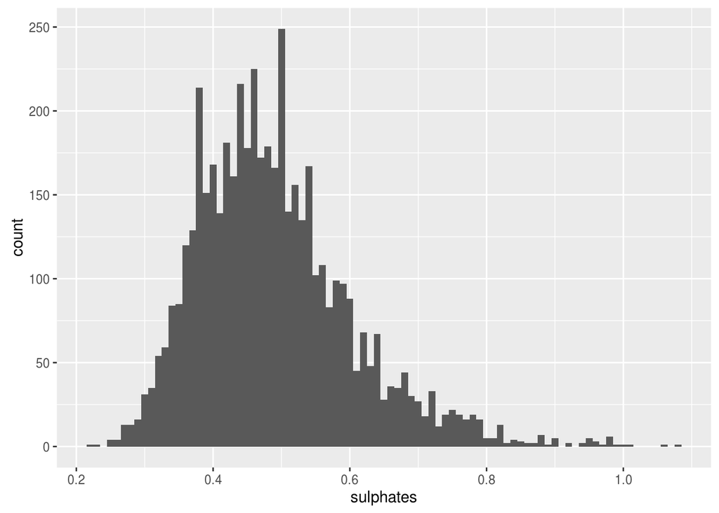

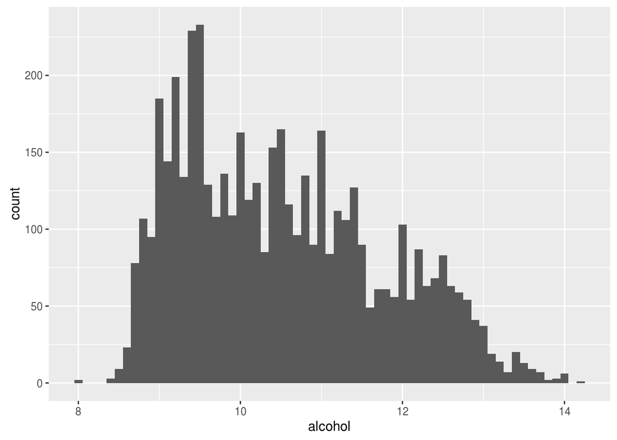

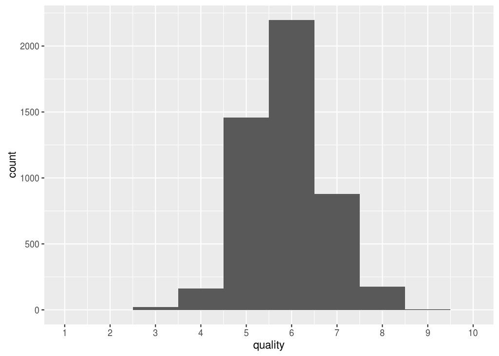

```
##    Min. 1st Qu.  Median    Mean 3rd Qu.    Max.
##   3.000   5.000   6.000   5.878   6.000   9.000
```

```
##
##    3    4    5    6    7    8    9
##   20  163 1457 2198  880  175    5
```

One intresting thing is that no one wine have rating of 10 and most of the wines have rating 5 and 6 i.e. most of the wines have average rating.

# Univariate Analysis

### What is the structure of your dataset?

There are 4900 observations on the white wines having 11 variables( ) quantifying the chemical properties of wines. One variable quality which contain the quality rating of wines.

**quality:** 1,2,3,4,5,6,7,8,9,10

Other Observations:

- Fixed Acidity of almost 80% wines are from 6 to 8.
- There is no one wine having quality rating 10.
- Most of the wines have quality rating 5 or 6.

### What is/are the main feature(s) of interest in your dataset?

Main feature of interest in this dataset is the quality of the wine. I’d like to determine which chemical property of wine effects it’s quality most.

### What other features in the dataset do you think will help support your investigation into your feature(s) of interest?

Acidity, amount of sulfur dioxide in the wine most likely contribute to the quality of wine. Density of wine also help to predict the quality.

### Of the features you investigated, were there any unusual distributions? Did you perform any operations on the data to tidy, adjust, or change the form of the data? If so, why did you do this?

No, there is no any unusual distribution of data.

# Bivariate Plots Section

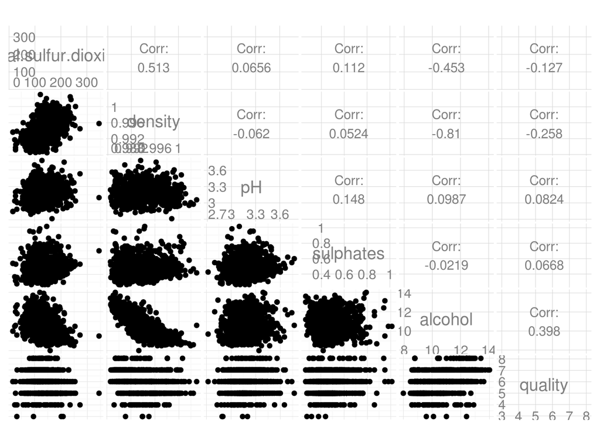

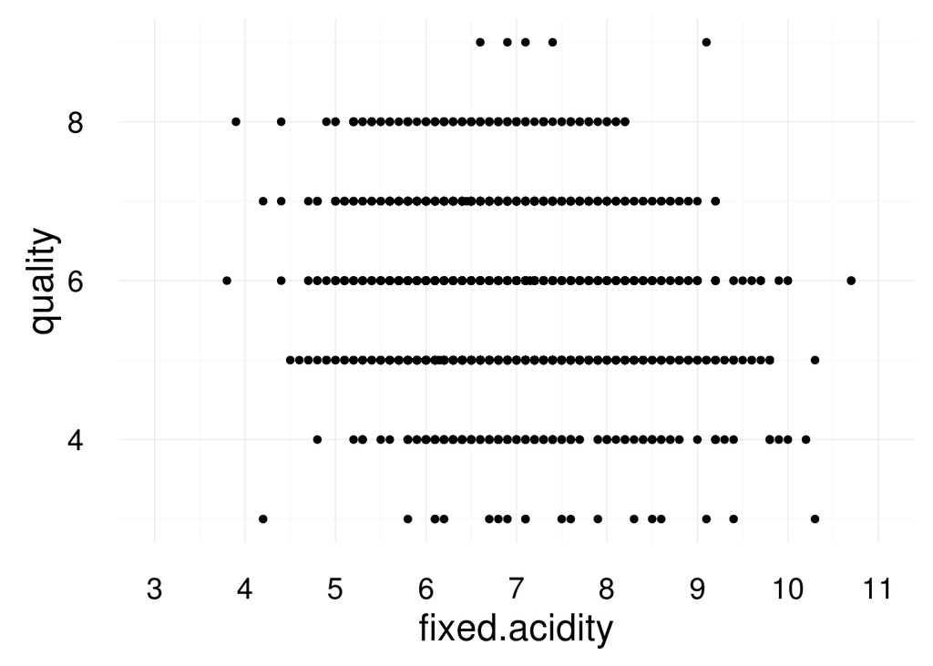

```
## [1] -0.1136628
```

```
## wineData$quality: 3
##    Min. 1st Qu.  Median    Mean 3rd Qu.    Max.
##   4.200   6.575   7.300   7.600   8.525  11.800
## --------------------------------------------------------
## wineData$quality: 4
##    Min. 1st Qu.  Median    Mean 3rd Qu.    Max.
##   4.800   6.400   6.900   7.129   7.600  10.200
## --------------------------------------------------------
## wineData$quality: 5
##    Min. 1st Qu.  Median    Mean 3rd Qu.    Max.
##   4.500   6.400   6.800   6.934   7.400  10.300
## --------------------------------------------------------
## wineData$quality: 6
##    Min. 1st Qu.  Median    Mean 3rd Qu.    Max.
##   3.800   6.300   6.800   6.838   7.300  14.200
## --------------------------------------------------------
## wineData$quality: 7
##    Min. 1st Qu.  Median    Mean 3rd Qu.    Max.
##   4.200   6.200   6.700   6.735   7.200   9.200
## --------------------------------------------------------
## wineData$quality: 8
##    Min. 1st Qu.  Median    Mean 3rd Qu.    Max.
##   3.900   6.200   6.800   6.657   7.300   8.200
## --------------------------------------------------------
## wineData$quality: 9
##    Min. 1st Qu.  Median    Mean 3rd Qu.    Max.
##    6.60    6.90    7.10    7.42    7.40    9.10
```

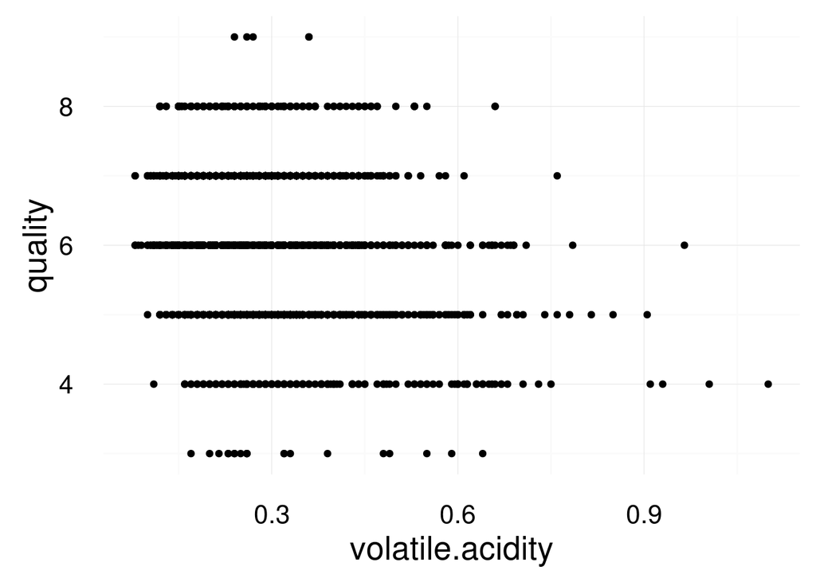

```
## [1] -0.194723
```

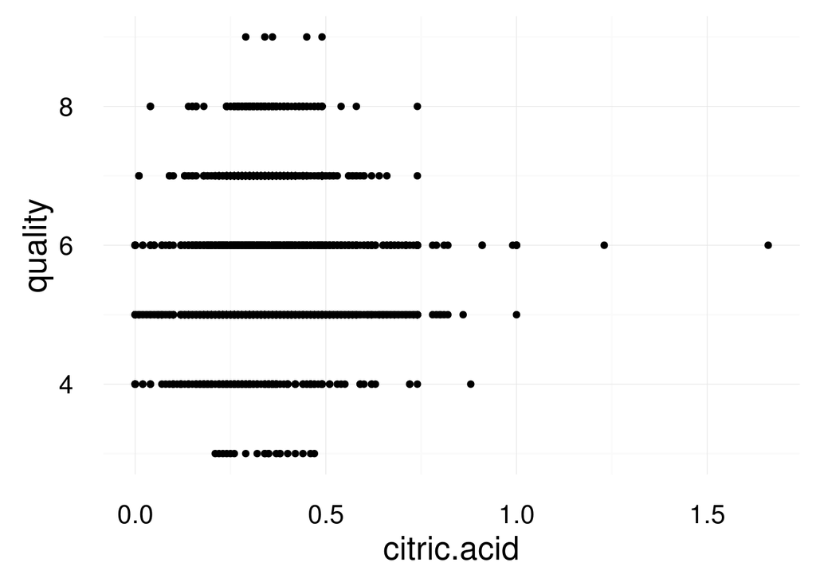

```
## [1] -0.009209091
```

Acidity of wine does not effect its quality. Fixed Acidity, Volatile acidity and citric acid is common in all quality rating of wine. Because acidity does not effect as much the quality of wine. Let’s check another variable how much they effect quality rating.

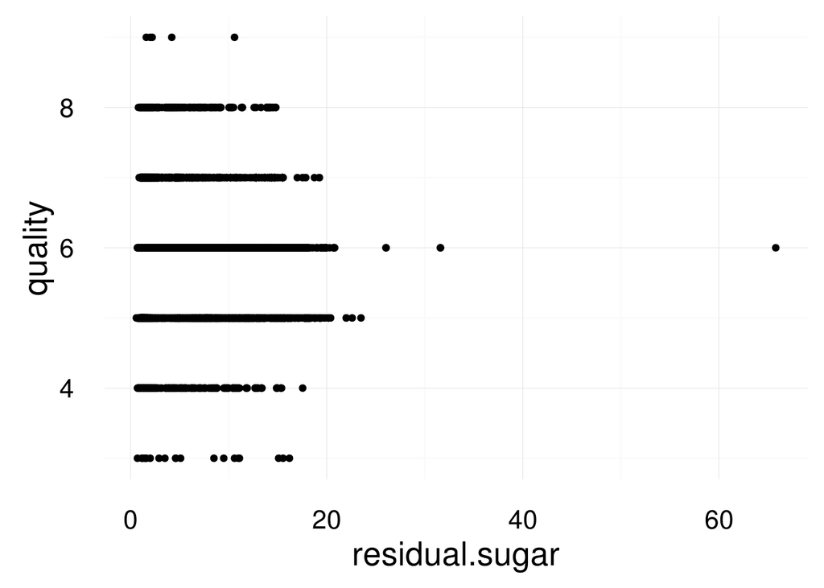

```
## [1] -0.09757683
```

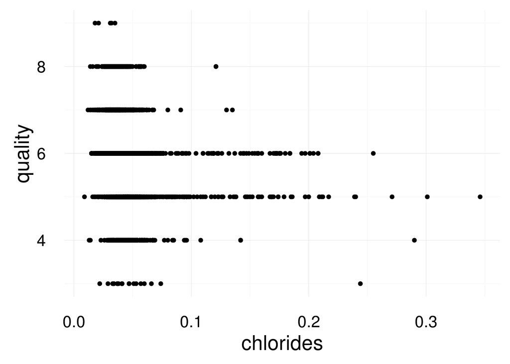

```
## [1] -0.2099344
```

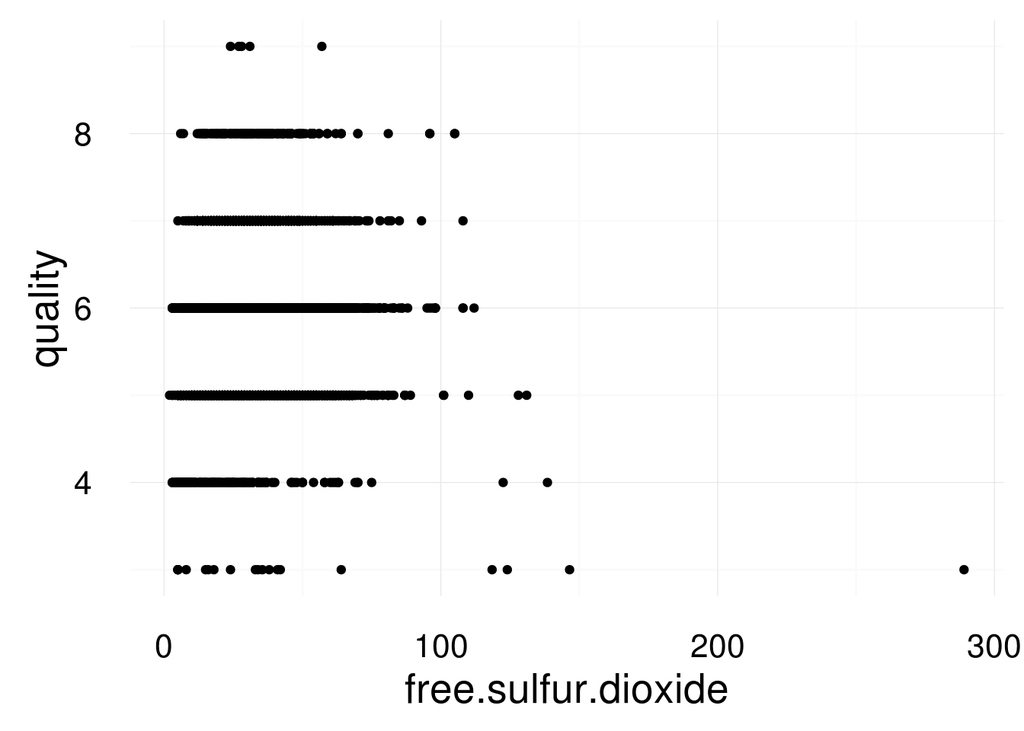

```
## [1] 0.008158067
```

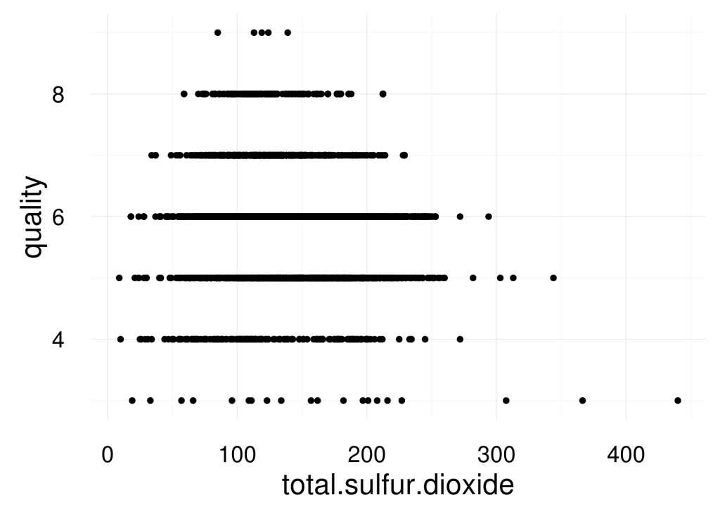

```
## [1] -0.1747372
```

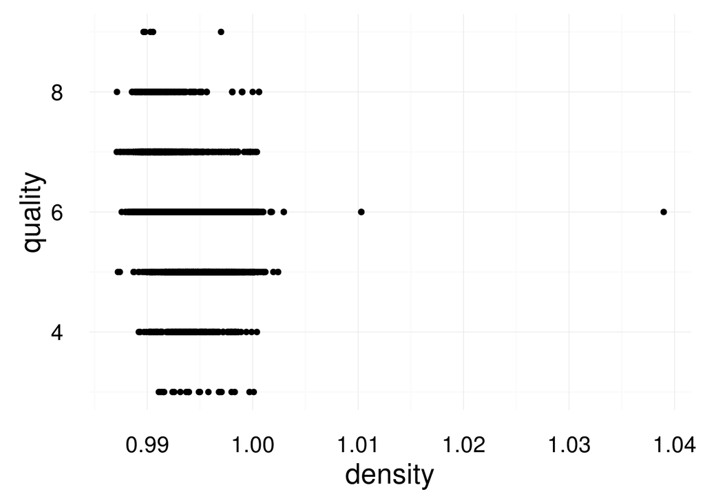

```
## [1] -0.3071233
```

```
## wineData$quality: 3
##    Min. 1st Qu.  Median    Mean 3rd Qu.    Max.
##  0.9911  0.9925  0.9944  0.9949  0.9969  1.0000
## --------------------------------------------------------
## wineData$quality: 4
##    Min. 1st Qu.  Median    Mean 3rd Qu.    Max.
##  0.9892  0.9926  0.9941  0.9943  0.9958  1.0000
## --------------------------------------------------------
## wineData$quality: 5
##    Min. 1st Qu.  Median    Mean 3rd Qu.    Max.
##  0.9872  0.9933  0.9953  0.9953  0.9972  1.0020
## --------------------------------------------------------
## wineData$quality: 6
##    Min. 1st Qu.  Median    Mean 3rd Qu.    Max.
##  0.9876  0.9917  0.9937  0.9940  0.9959  1.0390
## --------------------------------------------------------
## wineData$quality: 7
##    Min. 1st Qu.  Median    Mean 3rd Qu.    Max.
##  0.9871  0.9906  0.9918  0.9925  0.9937  1.0000
## --------------------------------------------------------
## wineData$quality: 8
##    Min. 1st Qu.  Median    Mean 3rd Qu.    Max.
##  0.9871  0.9903  0.9916  0.9922  0.9935  1.0010
## --------------------------------------------------------
## wineData$quality: 9
##    Min. 1st Qu.  Median    Mean 3rd Qu.    Max.
##  0.9896  0.9898  0.9903  0.9915  0.9906  0.9970
```

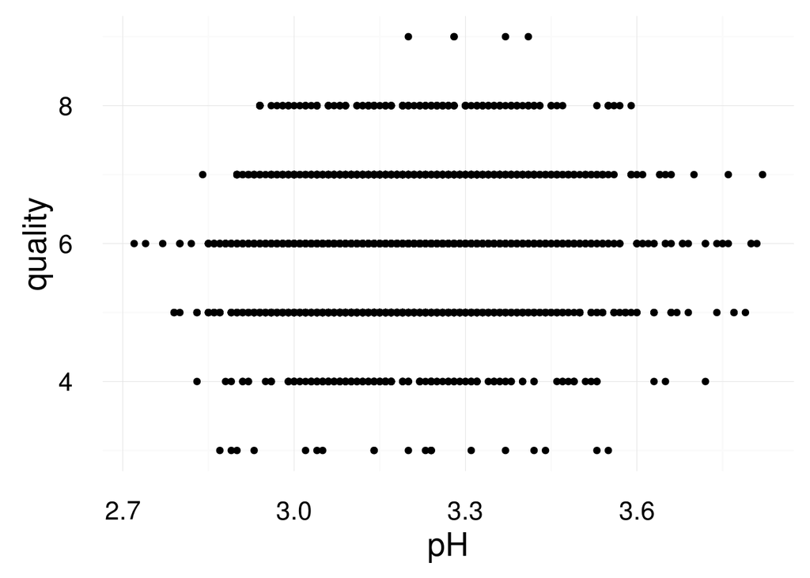

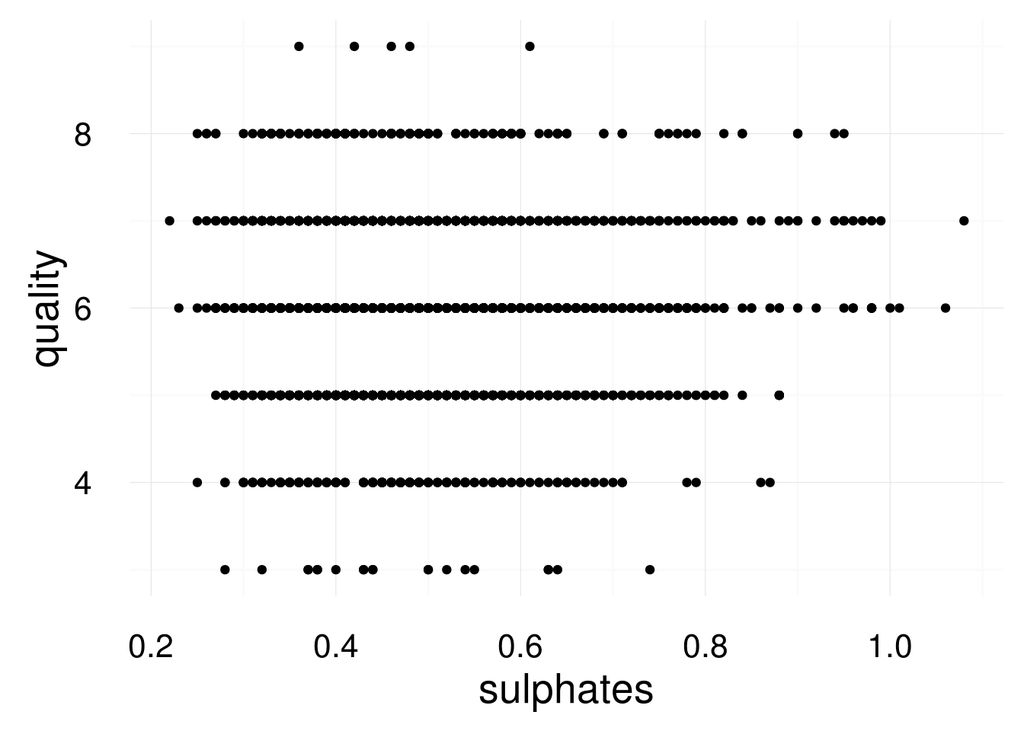